# Final Project - STAT 184

Tanuj Gaikwad

April 28, 2022

### Load Packages & Read in Data

```r
library(tidyverse, warn.conflicts = FALSE)
library(lubridate)
options(dplyr.summarise.inform = FALSE)

Movies = read.csv("movies.csv")
Ratings = read.csv("ratings.csv")
Tags = read.csv("tags.csv")
```

### Data Wrangle the Timestamps

```r
Ratings <-
  Ratings %>%
  mutate(rating_date = as_datetime(timestamp))

Tags <-
  Tags %>%
  mutate(tag_date = as_datetime(timestamp))

head(Ratings, 3)
```

|  | userId | movieId | rating | timestamp | rating_date |
| --- | --- | --- | --- | --- | --- |
| 1 | 1 | 1 | 4 | 964982703 | 2000-07-30 18:45:03 |
| 2 | 1 | 3 | 4 | 964981247 | 2000-07-30 18:20:47 |
| 3 | 1 | 6 | 4 | 964982224 | 2000-07-30 18:37:04 |

```r
head(Tags, 3)
```

|  | userId | movieId | tag | timestamp | tag_date |
| --- | --- | --- | --- | --- | --- |
| 1 | 2 | 60756 | funny | 1445714994 | 2015-10-24 19:29:54 |
| 2 | 2 | 60756 | Highly quotable | 1445714996 | 2015-10-24 19:29:56 |
| 3 | 2 | 60756 | will ferrell | 1445714992 | 2015-10-24 19:29:52 |

### Joining data where Person RATED & TAGGED a movie

```r
Ratings_n_Tags <-
  Tags %>%
  left_join(Ratings, by = c("movieId", "userId")) %>%
  left_join(Movies, by = "movieId") %>%
  na.omit() %>%
  select(userId, rating, rating_date, tag, tag_date, title, genres)

head(Ratings_n_Tags, 3)
```

|  | userId | rating | rating_date | tag | tag_date | title | genres |
| --- | --- | --- | --- | --- | --- | --- | --- |
| 1 | 2 | 5 | 2015-10-24 19:29:40 | funny | 2015-10-24 19:29:54 | Step Brothers (2008) | Comedy |
| 2 | 2 | 5 | 2015-10-24 19:29:40 | Highly quotable | 2015-10-24 19:29:56 | Step Brothers (2008) | Comedy |
| 3 | 2 | 5 | 2015-10-24 19:29:40 | will ferrell | 2015-10-24 19:29:52 | Step Brothers (2008) | Comedy |

### New release_year column and modifying movie titles to remove years

```r
Ratings_n_Tags <-
  Ratings_n_Tags %>%
  mutate(release_year = str_extract(title, "\\d+"))

Ratings_n_Tags$title <- gsub("\\(\\d+)", "", Ratings_n_Tags$title)

head(Ratings_n_Tags, 3)
```

|  | userId | rating | rating_date | tag | tag_date | title | genres | release_year |
| --- | --- | --- | --- | --- | --- | --- | --- | --- |
| 1 | 2 | 5 | 2015-10-24 19:29:40 | funny | 2015-10-24 19:29:54 | Step Brothers | Comedy | 2008 |
| 2 | 2 | 5 | 2015-10-24 19:29:40 | Highly quotable | 2015-10-24 19:29:56 | Step Brothers | Comedy | 2008 |
| 3 | 2 | 5 | 2015-10-24 19:29:40 | will ferrell | 2015-10-24 19:29:52 | Step Brothers | Comedy | 2008 |

### Data Visualization: First Graph

### Top 10 Rated Movie Genres (10 Most Frequently Rated Genres)

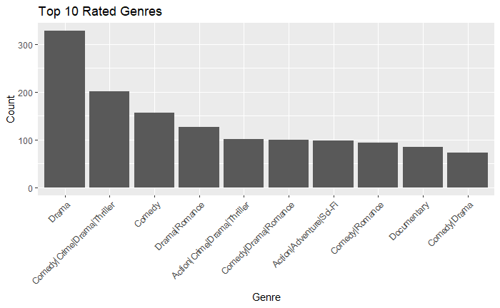

```r
# Data Visualization: First Graph
# Top 10 Rated Movie Genres (10 Most Frequently Rated Genres)

#Quick Data Wrangle to get the top 10 Genres
GenreCounts <-
  Ratings_n_Tags %>%
  group_by(genres) %>%
  summarise(count = n()) %>%
  arrange(desc(count)) %>%
  head(10)

ggplot(GenreCounts, aes(x = reorder(genres, -count), y = count)) +
  geom_bar(stat = "identity") +
  labs(y = "Count", x = "Genre", title = "Top 10 Rated Genres") +
  theme(axis.text.x = element_text(angle = 45, hjust = 1))
```

### Data Visualization: Second Graph

### Determine Count of each rating

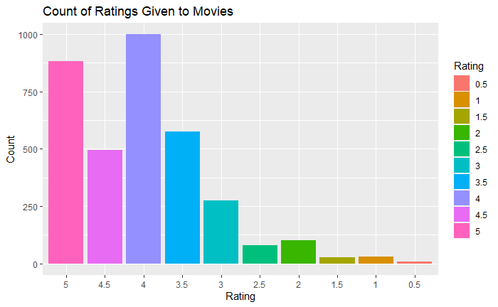

```r
#Quick Data Wrangle to get count of all ratings
RatingsCount <-
  Ratings_n_Tags %>%
  group_by(rating) %>%
  summarise(count = n()) %>%
  arrange(desc(rating))

#GGPlot Graph
ggplot(RatingsCount, aes(x = reorder(rating, -rating), y = count, fill = as.factor(rating))) +
  geom_bar(stat = "identity") +
  labs(y = "Count", x = "Rating", title = "Count of Ratings Given to Movies", fill = "Rating", color = "Rating")
```

This graph is a showing of how many movies got a certain rating by an individual user. As evident, the majority of the ratings are closer to the higher end with the most ratings coming in for 4 stars and the second most for 5 stars. It seems raters would rather put a whole number rating for the movie rather than a half a rating, but the count for the 3.5-star ratings versus the 3-Star and 4-Star ratings is showing itself to be the exception. Overall, people would more rather rate a movie positively than negatively to boost its score instead of dropping it after viewing it.

### Resources

1. https://statisticsglobe.com/r-remove-data-frame-rows-with-some-or-all-na
2. https://rawgit.com/rstudio/cheatsheets/main/lubridate.pdf
3. https://rstudio-pubs-static.s3.amazonaws.com/74603_76cd14d5983f47408fdf0b323550b846.html
4. https://www.rstudio.com/resources/cheatsheets/